# EAB Second Analysis

**UFO Sightings & Disasters**

- What top county has been affected most by disasters (E)
  - What kinds of UFO shapes have been reported there? Show with a descending horizontal barplot
- What county has the most reported UFO sightings (E)
  - What are the types of disasters that happen there? Show with a descending horizontal barplot
- Choose the state with the longest declared disaster on a given month/year (E)
  - What counties were affected?
  - Match all the counties in the UFO sightings to those of in the disasters
  - Are there any reported sightings that fall between that month/year?
  - If so, how many sightings were reported and what types of UFO shapes were seen?
- What is the top UFO sighting that was reported by multiple people on a given day? (E)
  - What county was it in?
  - What kind of disasters happen in that county?
  - What shape of UFOs are being seen in that county 5 years before after that incident? Show with a time series plot

```python
import pandas as pd
import numpy as np
import os
import matplotlib.pyplot as plt
from datetime import datetime
from pandas import Series, DataFrame, Panel
```

```python
ufo = pd.read_csv("ufos_complete.csv")
ufo = ufo.iloc[0:67346]
disaster = pd.read_csv("disasters.csv")
```

```python
# WHAT TOP COUNTY HAS BEEN AFFECTED MOST BY DISASTERS

# Based on US ufo sighting heat map, check CA, NY, WA, AZ, TX, FL
# Top county is Los Angeles County with 40 hits

ca_dist = disaster[disaster['state'] == 'California']
ca_dist['county'].value_counts()[0:5]
```

```
Los Angeles County       40
Riverside County         28
San Bernardino County    26
San Diego County         22
Ventura County           19
Name: county, dtype: int64
```

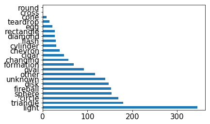

```python
# Reported UFO shapes

ca = ufo[ufo['state'] == 'California']
la = ca[ca['county'] == 'Los Angeles County']
shapecount = la['shape'].value_counts()
shapecount.plot.barh()
plt.show()
```

```python
la
```

|  | date_seen | date_posted | shape | duration_min | comments | city_raw | city | county | county_fip | zip_code | state | state_abbr | division_name | region_name | latitude | longitude |
| --- | --- | --- | --- | --- | --- | --- | --- | --- | --- | --- | --- | --- | --- | --- | --- | --- |
| 29 | 1965-06-01 13:00:00 | 2000-04-26 | cylinder | 0.083333 | At about 4 years of age&#44 I observed a cylin... | Long Beach | Long Beach | Los Angeles County | CA-037 | 90802 | California | CA | Pacific | West | 33.766944 | -118.188333 |
| 39 | 1965-06-15 03:30:00 | 2002-05-14 | circle | 2.000000 | Circular black object in early morning sky&#44... | Woodland Hills | Woodland Hills | Los Angeles County | CA-037 | 91364 | California | CA | Pacific | West | 34.168333 | -118.605000 |
| 73 | 1965-07-10 20:00:00 | 2012-07-04 | other | 60.000000 | The shape of the object looked- like a parach... | San Fernando | San Fernando | Los Angeles County | CA-037 | 91340 | California | CA | Pacific | West | 34.281944 | -118.438056 |
| 75 | 1965-07-12 18:30:00 | 2008-06-12 | cigar | 0.250000 | 7/12/65 Santa Monica&#44 California Cigar s... | Los Angeles | Los Angeles | Los Angeles County | CA-037 | 90012 | California | CA | Pacific | West | 34.052222 | -118.242778 |
| 108 | 1965-08-11 21:00:00 | 2012-12-20 | oval | 5.000000 | UFO at Culver City Drive-in 1965. | Culver City | Culver City | Los Angeles County | CA-037 | 90232 | California | CA | Pacific | West | 34.021111 | -118.395556 |
| 139 | 1965-10-07 10:00:00 | 2012-09-24 | disk | 3.000000 | Formation of disks decending behind trees w/mu... | Reseda | Reseda | Los Angeles County | CA-037 | 91335 | California | CA | Pacific | West | 34.201111 | -118.535556 |
| 227 | 1966-06-12 01:30:00 | 2010-08-24 | light | 5.000000 | Single Light UFO moving over Los Angeles&#44 A... | Playa Del Rey | Playa Del Rey | Los Angeles County | CA-037 | 90293 | California | CA | Pacific | West | 33.948889 | -118.444722 |
| 273 | 1966-07-15 21:00:00 | 2001-08-20 | triangle | 5.000000 | 3 triangle lights racing across the sky playin... | La Puente | La Puente | Los Angeles County | CA-037 | 91744 | California | CA | Pacific | West | 34.020000 | -117.948611 |
| 276 | 1966-07-15 22:00:00 | 2004-12-14 | triangle | 0.250000 | Huge triangler shape object seen up close over... | Malibu | Malibu | Los Angeles County | CA-037 | 90265 | California | CA | Pacific | West | 34.005000 | -118.809167 |
| 305 | 1966-09-15 20:00:00 | 2012-01-24 | cigar | 5.000000 | Blue cigar shape ufo seen over home in califor... | Canoga Park | Canoga Park | Los Angeles County | CA-037 | 91303 | California | CA | Pacific | West | 34.201111 | -118.597222 |
| 344 | 1967-03-01 19:30:00 | 2005-04-16 | oval | 0.033333 | Two observers witnessed 500-foot long oval cra... | Whittier | Whittier | Los Angeles County | CA-037 | 90601 | California | CA | Pacific | West | 33.979167 | -118.031944 |
| 361 | 1967-04-15 22:00:00 | 2006-10-30 | formation | 3.000000 | 3 bright colored lights comming straight at me... | North Hollywood | North Hollywood | Los Angeles County | CA-037 | 91601 | California | CA | Pacific | West | 34.172222 | -118.378056 |
| 439 | 1967-08-01 20:00:00 | 1999-01-28 | unknown | 2.000000 | Light in sky with amazing accelleration proper... | Downey (North American Aviation) | Downey | Los Angeles County | CA-037 | 90241 | California | CA | Pacific | West | 33.940000 | -118.131667 |
| 459 | 1967-08-25 23:30:00 | 2009-01-10 | oval | 5.000000 | Oval light (the size of a five story building)... | Playa Del Rey | Playa Del Rey | Los Angeles County | CA-037 | 90293 | California | CA | Pacific | West | 33.948889 | -118.444722 |
| 467 | 1967-09-08 15:00:00 | 2004-01-22 | cigar | 2.000000 | 5 Red Glowing Cigar Shaped Ships Sighted at He... | Hermosa Beach | Hermosa Beach | Los Angeles County | CA-037 | 90254 | California | CA | Pacific | West | 33.862222 | -118.398611 |
| 475 | 1967-09-20 21:00:00 | 2006-05-15 | triangle | 5.000000 | I noticed a light that appeard to be above the... | Woodland Hills | Woodland Hills | Los Angeles County | CA-037 | 91364 | California | CA | Pacific | West | 34.168333 | -118.605000 |
| 487 | 1967-10-15 21:00:00 | 2003-12-19 | fireball | 15.000000 | A fireball over the San Fernando Valley in 1967 | North Hollywood | North Hollywood | Los Angeles County | CA-037 | 91601 | California | CA | Pacific | West | 34.172222 | -118.378056 |
| 488 | 1967-10-15 23:00:00 | 2009-03-19 | light | 3.000000 | oct. 1967 late night&#44 I was a high school s... | Saugus | Santa Clarita | Los Angeles County | CA-037 | 91350 | California | CA | Pacific | West | 34.411389 | -118.539167 |
| 501 | 1968-01-01 00:00:00 | 2009-12-12 | circle | 1.000000 | Craft with a portal | Lawndale | Lawndale | Los Angeles County | CA-037 | 90260 | California | CA | Pacific | West | 33.887222 | -118.351667 |
| 560 | 1968-06-10 20:30:00 | 2004-08-11 | disk | 5.000000 | Saucer with dome &amp; windows hovering errati... | Woodland Hills | Woodland Hills | Los Angeles County | CA-037 | 91364 | California | CA | Pacific | West | 34.168333 | -118.605000 |
| 566 | 1968-06-15 15:00:00 | 2003-05-27 | cylinder | 10.000000 | Observed a very long&#44 shiny object over the... | Canoga Park | Canoga Park | Los Angeles County | CA-037 | 91303 | California | CA | Pacific | West | 34.201111 | -118.597222 |
| 589 | 1968-06-30 01:00:00 | 2010-11-21 | sphere | 7.000000 | A sphere of blue/white light/energy descended ... | Whittier | Whittier | Los Angeles County | CA-037 | 90601 | California | CA | Pacific | West | 33.979167 | -118.031944 |
| 620 | 1968-07-15 07:00:00 | 1999-04-02 | cigar | 20.000000 | Myself and my friend observed a cigar-shaped c... | Rosemead | Rosemead | Los Angeles County | CA-037 | 91770 | California | CA | Pacific | West | 34.080556 | -118.071944 |
| 653 | 1968-08-15 20:00:00 | 2012-07-04 | light | 10.000000 | A bright star grew larged and exploded in the ... | Pomona | Pomona | Los Angeles County | CA-037 | 91766 | California | CA | Pacific | West | 34.055278 | -117.751389 |
| 672 | 1968-10-10 13:00:00 | 2003-10-31 | circle | 5.000000 | ROUND &#44 ORANGE &#44 WITH WHAT I WOULD SAY W... | Hawthorne | Hawthorne | Los Angeles County | CA-037 | 90250 | California | CA | Pacific | West | 33.916389 | -118.351667 |
| 717 | 1969-06-01 12:00:00 | 2000-12-02 | formation | 30.000000 | ufo seen over school by entire school. | La Puenty | La Puente | Los Angeles County | CA-037 | 91744 | California | CA | Pacific | West | 34.020011 | -117.949508 |
| 752 | 1969-07-01 18:00:00 | 2000-02-16 | disk | 7.000000 | In the summer of 1969 living in Starlight Esta... | Whittier | Whittier | Los Angeles County | CA-037 | 90601 | California | CA | Pacific | West | 33.979167 | -118.031944 |
| 798 | 1969-08-17 02:30:00 | 1999-11-02 | sphere | 10.000000 | Was up late watching TV and glanced out of nea... | North Hollywood | North Hollywood | Los Angeles County | CA-037 | 91601 | California | CA | Pacific | West | 34.172222 | -118.378056 |
| 839 | 1970-02-10 20:30:00 | 2001-08-05 | disk | 10.000000 | I sighted a disc shaped object hovering above ... | Los Angeles | Los Angeles | Los Angeles County | CA-037 | 90012 | California | CA | Pacific | West | 34.052222 | -118.242778 |
| 910 | 1970-08-01 21:30:00 | 1999-10-02 | cylinder | 3.000000 | A flaming cylindrical object crossed the entir... | Palmdale | Palmdale | Los Angeles County | CA-037 | 93550 | California | CA | Pacific | West | 34.579444 | -118.115556 |
| ... | ... | ... | ... | ... | ... | ... | ... | ... | ... | ... | ... | ... | ... | ... | ... | ... |
| 67695 | 2014-01-18 18:00:00 | 2014-01-24 | sphere | 5.000000 | Saw a reddish light move up from the little tu... | Tujunga | Tujunga | Los Angeles County | CA-037 | 91042 | California | CA | Pacific | West | 34.252222 | -118.287500 |
| 67898 | 2014-01-29 19:34:00 | 2014-01-30 | circle | 10.000000 | Several orange-pinkish lights in sky looking e... | Santa Clarita | Newhall | Los Angeles County | CA-037 | 91321 | California | CA | Pacific | West | 34.391667 | -118.541667 |
| 67960 | 2014-02-01 20:58:00 | 2014-02-07 | light | 5.000000 | Fleet of multiple pulsating color spheres. | Covina | Covina | Los Angeles County | CA-037 | 91723 | California | CA | Pacific | West | 34.090000 | -117.889444 |
| 68048 | 2014-02-07 23:40:00 | 2014-02-14 | triangle | 25.000000 | Bright row of lights over Woodland Hills. | Woodland Hills | Woodland Hills | Los Angeles County | CA-037 | 91364 | California | CA | Pacific | West | 34.168333 | -118.605000 |
| 68152 | 2014-02-15 01:59:00 | 2014-02-21 | unknown | 2.033333 | Strange aircraft with bright red flashing lights. | City Of Industry | La Puente | Los Angeles County | CA-037 | 91746 | California | CA | Pacific | West | 34.019734 | -117.958675 |
| 68234 | 2014-02-20 23:29:00 | 2014-02-27 | circle | 4.000000 | Fiery orange-red orbs traveling at steady pace... | Venice | Venice | Los Angeles County | CA-037 | 90291 | California | CA | Pacific | West | 33.990833 | -118.459167 |
| 68247 | 2014-02-21 19:20:00 | 2014-02-27 | unknown | 10.000000 | They looked like stars that were in a straight... | Monrovia | Monrovia | Los Angeles County | CA-037 | 91016 | California | CA | Pacific | West | 34.148056 | -117.998056 |
| 68315 | 2014-02-23 21:55:00 | 2014-02-27 | diamond | 5.000000 | Ten diamond shape objects floating in the sky. | Temple City | Temple City | Los Angeles County | CA-037 | 91780 | California | CA | Pacific | West | 34.107222 | -118.056944 |
| 68317 | 2014-02-23 23:00:00 | 2014-03-18 | circle | 60.000000 | Circular craft that hovered for 1 hour near do... | Los Angeles | Los Angeles | Los Angeles County | CA-037 | 90012 | California | CA | Pacific | West | 34.052222 | -118.242778 |
| 68487 | 2014-03-08 00:00:00 | 2014-03-18 | sphere | 0.066667 | bright green glowing ball | Carson | Carson | Los Angeles County | CA-037 | 90745 | California | CA | Pacific | West | 33.831389 | -118.281111 |
| 68492 | 2014-03-08 14:00:00 | 2014-03-18 | teardrop | 120.000000 | Hi i saw 3 lights coming down over my house bu... | Pomona | Pomona | Los Angeles County | CA-037 | 91766 | California | CA | Pacific | West | 34.055278 | -117.751389 |
| 68503 | 2014-03-09 16:45:00 | 2014-03-18 | other | 2.000000 | Bright Pinpoint of Light Near Aircraft Contrail. | Toluca Lake | North Hollywood | Los Angeles County | CA-037 | 91602 | California | CA | Pacific | West | 34.150179 | -118.354961 |
| 68672 | 2014-03-22 21:00:00 | 2014-03-27 | disk | 20.000000 | It was about 21:00 a friend came to visit whil... | Reseda | Reseda | Los Angeles County | CA-037 | 91335 | California | CA | Pacific | West | 34.201111 | -118.535556 |
| 68681 | 2014-03-23 19:50:00 | 2014-03-27 | flash | 0.016667 | Big flash of light in sky. | Lawndale | Lawndale | Los Angeles County | CA-037 | 90260 | California | CA | Pacific | West | 33.887222 | -118.351667 |
| 68689 | 2014-03-24 05:53:00 | 2014-04-04 | triangle | 3.000000 | Three Silver Reflective Triangular Shaped Obje... | Lancaster | Lancaster | Los Angeles County | CA-037 | 93534 | California | CA | Pacific | West | 34.698056 | -118.135833 |
| 68857 | 2014-04-05 14:40:00 | 2014-04-11 | cylinder | 4.000000 | A small vertical cylinder hovered me for over ... | La Crescenta | La Crescenta | Los Angeles County | CA-037 | 91214 | California | CA | Pacific | West | 34.224167 | -118.239167 |
| 68980 | 2014-04-11 05:20:00 | 2014-04-18 | other | 20.000000 | Two objects...each a &#39row of lights&#39 ove... | West Los Angeles | Los Angeles | Los Angeles County | CA-037 | 90012 | California | CA | Pacific | West | 34.052222 | -118.242778 |
| 69038 | 2014-04-14 20:00:00 | 2014-04-24 | light | 0.750000 | Green and red lights hovering and dipping. | West Hollywood | Los Angeles | Los Angeles County | CA-037 | 90028 | California | CA | Pacific | West | 34.098333 | -118.325833 |
| 69050 | 2014-04-15 00:00:00 | 2014-04-18 | cylinder | 0.133333 | Small cylinder flying across the sky during th... | Glendora | Glendora | Los Angeles County | CA-037 | 91741 | California | CA | Pacific | West | 34.136111 | -117.864444 |
| 69052 | 2014-04-15 01:00:00 | 2014-04-18 | light | 0.083333 | Two faint bluish-white lights streak in a slig... | Los Angeles | Los Angeles | Los Angeles County | CA-037 | 90012 | California | CA | Pacific | West | 34.052222 | -118.242778 |
| 69063 | 2014-04-15 08:54:00 | 2014-04-18 | sphere | 0.333333 | Extremely fast glowing object&#44 flying very ... | San Fernando Valley | Van Nuys | Los Angeles County | CA-037 | 91401 | California | CA | Pacific | West | 34.182578 | -118.439676 |
| 69148 | 2014-04-20 12:45:00 | 2014-04-24 | cigar | 2.000000 | IUFO s over tennis courts. | Manhatten Beach | Manhattan Beach | Los Angeles County | CA-037 | 90266 | California | CA | Pacific | West | 33.884736 | -118.410909 |
| 69226 | 2014-04-24 22:26:00 | 2014-05-02 | light | 1.000000 | Ball of light with no strobe lights being chas... | Walnut | Walnut | Los Angeles County | CA-037 | 91789 | California | CA | Pacific | West | 34.020278 | -117.864444 |
| 69233 | 2014-04-25 21:05:00 | 2014-05-02 | oval | 0.166667 | Large oval shaped white light. | Canyon Country | Canyon Country | Los Angeles County | CA-037 | 91351 | California | CA | Pacific | West | 34.423333 | -118.471111 |
| 69251 | 2014-04-26 20:43:00 | 2014-05-02 | fireball | 2.000000 | Orange&#44 glowing fireball flying north; was ... | Whittier | Whittier | Los Angeles County | CA-037 | 90601 | California | CA | Pacific | West | 33.979167 | -118.031944 |
| 69270 | 2014-04-27 20:45:00 | 2014-05-02 | chevron | 0.250000 | South eastern sky at about 50-75 degrees above... | Chatsworth | Chatsworth | Los Angeles County | CA-037 | 91311 | California | CA | Pacific | West | 34.257222 | -118.600278 |
| 69273 | 2014-04-27 20:50:00 | 2014-05-02 | unknown | 20.000000 | 6 Red/Orange lights in formation seen in NW Sa... | Chatsworth | Chatsworth | Los Angeles County | CA-037 | 91311 | California | CA | Pacific | West | 34.257222 | -118.600278 |
| 69280 | 2014-04-27 21:30:00 | 2014-05-02 | circle | 2.000000 | ORANGE GLOWING ROUND LIGHTS IN SAN FERNANDO NI... | Chatsworth | Chatsworth | Los Angeles County | CA-037 | 91311 | California | CA | Pacific | West | 34.257222 | -118.600278 |
| 69316 | 2014-04-30 21:03:00 | 2014-05-02 | triangle | 0.033333 | Drone flying over head. under the airline flig... | Venice | Venice | Los Angeles County | CA-037 | 90291 | California | CA | Pacific | West | 33.990833 | -118.459167 |
| 69335 | 2014-05-01 21:00:00 | 2014-05-08 | light | 45.000000 | A star like object&#44 flashing red and blue a... | Los Angeles | Los Angeles | Los Angeles County | CA-037 | 90012 | California | CA | Pacific | West | 34.052222 | -118.242778 |

1910 rows × 16 columns

```python
shapecount = pd.DataFrame(shapecount)
shapecount = shapecount.reset_index()
```

```python
shapecount
```

|  | index | shape |
| --- | --- | --- |
| 0 | light | 345 |
| 1 | triangle | 180 |
| 2 | circle | 169 |
| 3 | sphere | 154 |
| 4 | fireball | 153 |
| 5 | disk | 147 |
| 6 | unknown | 140 |
| 7 | other | 117 |
| 8 | oval | 92 |
| 9 | formation | 69 |
| 10 | changing | 57 |
| 11 | cigar | 48 |
| 12 | chevron | 38 |
| 13 | cylinder | 30 |
| 14 | flash | 29 |
| 15 | diamond | 27 |
| 16 | rectangle | 27 |
| 17 | egg | 22 |
| 18 | teardrop | 15 |
| 19 | cone | 9 |
| 20 | cross | 1 |
| 21 | round | 1 |

```python
plt.rc('font', size=15)
```

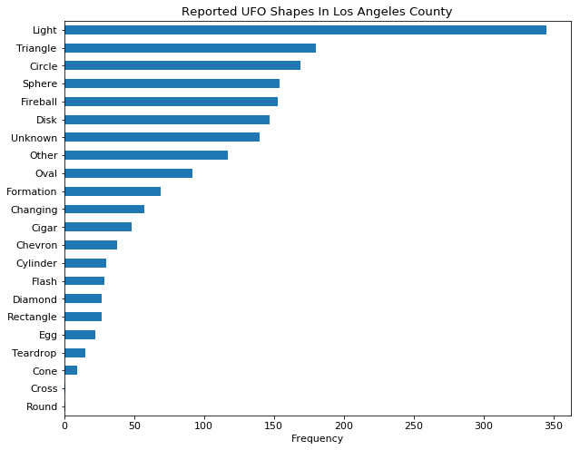

```python
shapecount = shapecount.sort_values('shape', ascending=True)
shapecount['index'] = shapecount['index'].str.title()
shapecount.plot.barh('index', 'shape', title='Reported UFO Shapes In Los Angeles County',
                        legend=False, figsize=(10, 8))
plt.ylabel('')
plt.xlabel('Frequency')
# plt.savefig('UFOsLAShapes.png', transparent=True)
plt.show()
```

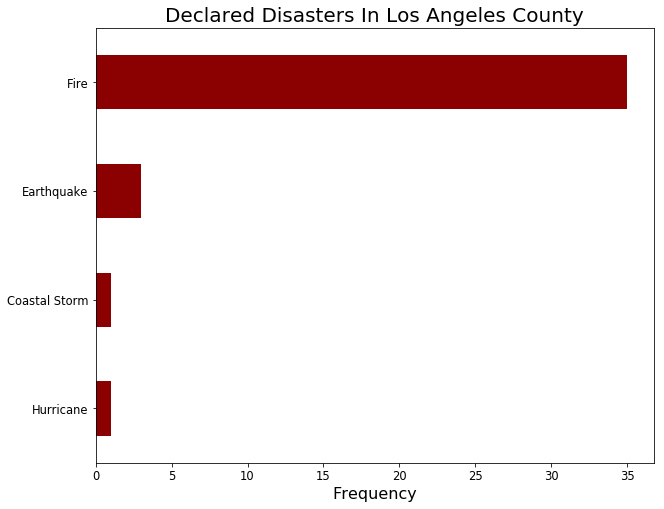

```python
# WHAT COUNTY HAS THE MOST REPORTED UFO SIGHTINGS
# Los Angeles has the most UFO sightings
# What disasters occur there?
plt.rc('font', size=11.5)
ca_dis = disaster[disaster['state'] == 'California']
la_dis = ca_dis[ca_dis['county'] == 'Los Angeles County']
dis_count = la_dis['disaster_type'].value_counts()
dis_count = pd.DataFrame(dis_count)
dis_count = dis_count.reset_index()
dis_count = dis_count.sort_values('disaster_type', ascending=True)
dis_count.plot.barh('index', 'disaster_type',
                        legend=False, figsize=(10, 8), color="darkred")
plt.title('Declared Disasters In Los Angeles County', size=20)
plt.ylabel('')
plt.xlabel('Frequency', size = 16)
plt.savefig('DisastersLA.png', transparent=True)
plt.show()
```

```python
la['comments'][la['comments'].str.contains('earth')]
```

```
7070     A Large Brilliant green fireball was seen &quo...
15193    Several dark objects traverse the moon on the ...
17719    white ball of light streaks to earth; makes a ...
18660    On the evening my daughter and witnessed two o...
21809    red glowing object splits&#44 then 1 splits of...
22087    I saw a bright object with a short tail that a...
27178    I saw a  green fireball travelling across the ...
31383    We saw a bright red fireball like object that ...
36401    Cirle of light in the sky&#44 moving along doi...
44850    I really know that what i saw was not of this ...
45474    Silent Black Silvery Triangular Object with re...
59724    Bright green lights hover over Los Angeles the...
Name: comments, dtype: object
```

```python
disaster.sort('days_lasted', ascending = 0)
```

|  | date_started | date_ended | declaration_type | disaster_type | disaster_title | days_lasted | county | county_fip | state | state_abbr | division_name | region_name | latitude | longitude |
| --- | --- | --- | --- | --- | --- | --- | --- | --- | --- | --- | --- | --- | --- | --- |
| 1055 | 1983-01-24 | 1997-01-27 | Major Disaster Declaration | Volcano | Lava Flow, Kilauea Volcano | 5117.0 | Hawaii County | HI-001 | Hawaii | HI | Pacific | West | 19.542915 | -155.665857 |
| 1654 | 1994-01-17 | 1994-11-30 | Major Disaster Declaration | Earthquake | Northridge Earthquake | 317.0 | Orange County | CA-059 | California | CA | Pacific | West | 33.717471 | -117.831143 |
| 1655 | 1994-01-17 | 1994-11-30 | Major Disaster Declaration | Earthquake | Northridge Earthquake | 317.0 | Ventura County | CA-111 | California | CA | Pacific | West | 34.370488 | -119.139064 |
| 1653 | 1994-01-17 | 1994-11-30 | Major Disaster Declaration | Earthquake | Northridge Earthquake | 317.0 | Los Angeles County | CA-037 | California | CA | Pacific | West | 34.052227 | -118.243660 |
| 1933 | 1996-02-23 | 1996-09-19 | Emergency Declaration | Fire | Extreme Fire Hazard | 209.0 | Brown County | TX-049 | Texas | TX | West South Central | South | 31.770510 | -98.924534 |
| 1932 | 1996-02-23 | 1996-09-19 | Emergency Declaration | Fire | Extreme Fire Hazard | 209.0 | Bell County | TX-027 | Texas | TX | West South Central | South | 31.134411 | -97.524724 |
| 1931 | 1996-02-23 | 1996-09-19 | Emergency Declaration | Fire | Extreme Fire Hazard | 209.0 | Dallas County | TX-113 | Texas | TX | West South Central | South | 32.802468 | -96.835100 |
| 1929 | 1996-02-23 | 1996-09-19 | Emergency Declaration | Fire | Extreme Fire Hazard | 209.0 | Trinity County | TX-455 | Texas | TX | West South Central | South | 31.068765 | -95.143207 |
| 1928 | 1996-02-23 | 1996-09-19 | Emergency Declaration | Fire | Extreme Fire Hazard | 209.0 | Rusk County | TX-401 | Texas | TX | West South Central | South | 32.174189 | -94.810595 |
| 1927 | 1996-02-23 | 1996-09-19 | Emergency Declaration | Fire | Extreme Fire Hazard | 209.0 | Tyler County | TX-457 | Texas | TX | West South Central | South | 30.732445 | -94.315422 |
| 1930 | 1996-02-23 | 1996-09-19 | Emergency Declaration | Fire | Extreme Fire Hazard | 209.0 | Liberty County | TX-291 | Texas | TX | West South Central | South | 30.163359 | -94.810595 |
| 1935 | 1996-02-23 | 1996-09-19 | Emergency Declaration | Fire | Extreme Fire Hazard | 209.0 | Montgomery County | TX-339 | Texas | TX | West South Central | South | 30.321348 | -95.477781 |
| 1926 | 1996-02-23 | 1996-09-19 | Emergency Declaration | Fire | Extreme Fire Hazard | 209.0 | Sabine County | TX-403 | Texas | TX | West South Central | South | 31.297423 | -93.824824 |
| 1925 | 1996-02-23 | 1996-09-19 | Emergency Declaration | Fire | Extreme Fire Hazard | 209.0 | Marion County | TX-315 | Texas | TX | West South Central | South | 32.778068 | -94.356513 |
| 1924 | 1996-02-23 | 1996-09-19 | Emergency Declaration | Fire | Extreme Fire Hazard | 209.0 | Denton County | TX-121 | Texas | TX | West South Central | South | 33.141861 | -97.179026 |
| 1923 | 1996-02-23 | 1996-09-19 | Emergency Declaration | Fire | Extreme Fire Hazard | 209.0 | Bexar County | TX-029 | Texas | TX | West South Central | South | 29.420076 | -98.572102 |
| 1921 | 1996-02-23 | 1996-09-19 | Emergency Declaration | Fire | Extreme Fire Hazard | 209.0 | Parker County | TX-367 | Texas | TX | West South Central | South | 32.741552 | -97.872160 |
| 1934 | 1996-02-23 | 1996-09-19 | Emergency Declaration | Fire | Extreme Fire Hazard | 209.0 | Gregg County | TX-183 | Texas | TX | West South Central | South | 32.489255 | -94.852064 |
| 1936 | 1996-02-23 | 1996-09-19 | Emergency Declaration | Fire | Extreme Fire Hazard | 209.0 | San Saba County | TX-411 | Texas | TX | West South Central | South | 31.238909 | -98.748117 |
| 1918 | 1996-02-23 | 1996-09-19 | Emergency Declaration | Fire | Extreme Fire Hazard | 209.0 | Angelina County | TX-005 | Texas | TX | West South Central | South | 31.270470 | -94.645035 |
| 1919 | 1996-02-23 | 1996-09-19 | Emergency Declaration | Fire | Extreme Fire Hazard | 209.0 | Coryell County | TX-099 | Texas | TX | West South Central | South | 31.477436 | -97.872160 |
| 1937 | 1996-02-23 | 1996-09-19 | Emergency Declaration | Fire | Extreme Fire Hazard | 209.0 | Walker County | TX-471 | Texas | TX | West South Central | South | 30.681539 | -95.645795 |
| 1938 | 1996-02-23 | 1996-09-19 | Emergency Declaration | Fire | Extreme Fire Hazard | 209.0 | Bowie County | TX-037 | Texas | TX | West South Central | South | 33.447329 | -94.479976 |
| 1939 | 1996-02-23 | 1996-09-19 | Emergency Declaration | Fire | Extreme Fire Hazard | 209.0 | Fayette County | TX-149 | Texas | TX | West South Central | South | 29.889644 | -96.835100 |
| 1940 | 1996-02-23 | 1996-09-19 | Emergency Declaration | Fire | Extreme Fire Hazard | 209.0 | McLennan County | TX-309 | Texas | TX | West South Central | South | 31.518228 | -97.179026 |
| 1941 | 1996-02-23 | 1996-09-19 | Emergency Declaration | Fire | Extreme Fire Hazard | 209.0 | San Augustine County | TX-405 | Texas | TX | West South Central | South | 31.469936 | -94.151376 |
| 1942 | 1996-02-23 | 1996-09-19 | Emergency Declaration | Fire | Extreme Fire Hazard | 209.0 | Upshur County | TX-459 | Texas | TX | West South Central | South | 32.709975 | -94.976654 |
| 1943 | 1996-02-23 | 1996-09-19 | Emergency Declaration | Fire | Extreme Fire Hazard | 209.0 | Nacogdoches County | TX-347 | Texas | TX | West South Central | South | 31.635307 | -94.645035 |
| 1944 | 1996-02-23 | 1996-09-19 | Emergency Declaration | Fire | Extreme Fire Hazard | 209.0 | Camp County | TX-063 | Texas | TX | West South Central | South | 32.956704 | -94.997446 |
| 1945 | 1996-02-23 | 1996-09-19 | Emergency Declaration | Fire | Extreme Fire Hazard | 209.0 | Shelby County | TX-419 | Texas | TX | West South Central | South | 31.834302 | -94.151376 |
| ... | ... | ... | ... | ... | ... | ... | ... | ... | ... | ... | ... | ... | ... | ... |
| 10640 | 2009-04-09 | NaN | Fire Management Assistance | Fire | Mcclain County Fire | NaN | McClain County | OK-087 | Oklahoma | OK | West South Central | South | 35.028232 | -97.481416 |
| 10641 | 2009-04-09 | NaN | Fire Management Assistance | Fire | Midwest Choctaw Fire | NaN | Oklahoma County | OK-109 | Oklahoma | OK | West South Central | South | 35.603832 | -97.351656 |
| 10642 | 2009-04-09 | NaN | Fire Management Assistance | Fire | Healdton Carter Fire | NaN | Carter County | OK-019 | Oklahoma | OK | West South Central | South | 34.199625 | -97.351656 |
| 10643 | 2009-04-09 | NaN | Fire Management Assistance | Fire | Velma Fire | NaN | Stephens County | OK-137 | Oklahoma | OK | West South Central | South | 34.520347 | -97.872160 |
| 10663 | 2009-04-13 | NaN | Fire Management Assistance | Fire | Mulhall Fire | NaN | Payne County | OK-119 | Oklahoma | OK | West South Central | South | 36.144999 | -97.006839 |
| 10664 | 2009-04-23 | NaN | Fire Management Assistance | Fire | Highway 31 Fire | NaN | Horry County | SC-051 | South Carolina | SC | South Atlantic | South | 33.919657 | -78.928824 |
| 10667 | 2009-05-11 | NaN | Fire Management Assistance | Fire | Martin County Fire Complex | NaN | Martin County | FL-085 | Florida | FL | South Atlantic | South | 27.080493 | -80.410396 |
| 10671 | 2009-07-25 | NaN | Fire Management Assistance | Fire | Mill Flat Fire | NaN | Washington County | UT-053 | Utah | UT | Mountain | West | 37.322488 | -113.477610 |
| 10696 | 2010-05-23 | NaN | Fire Management Assistance | Fire | Cabazon Fire | NaN | Sandoval County | NM-043 | New Mexico | NM | Mountain | West | 35.602067 | -106.723464 |
| 10697 | 2010-06-01 | NaN | Fire Management Assistance | Fire | Rio Fire | NaN | Sandoval County | NM-043 | New Mexico | NM | Mountain | West | 35.602067 | -106.723464 |
| 10815 | 2010-09-19 | NaN | Fire Management Assistance | Fire | Machine Gun Fire | NaN | Salt Lake County | UT-035 | Utah | UT | Mountain | West | 40.644188 | -111.952249 |
| 10816 | 2011-02-19 | NaN | Fire Management Assistance | Fire | Smith Fire | NaN | Warren County | VA-187 | Virginia | VA | South Atlantic | South | 38.933175 | -78.247615 |
| 10817 | 2011-02-19 | NaN | Fire Management Assistance | Fire | Coffman Fire | NaN | Rockingham County | VA-165 | Virginia | VA | South Atlantic | South | 38.582592 | -78.883555 |
| 10818 | 2011-02-27 | NaN | Fire Management Assistance | Fire | Willow Creek South Fire Complex | NaN | Potter County | TX-375 | Texas | TX | West South Central | South | 35.404373 | -101.980461 |
| 10819 | 2011-02-27 | NaN | Fire Management Assistance | Fire | Tanglewood Fire Complex | NaN | Randall County | TX-381 | Texas | TX | West South Central | South | 34.902038 | -101.797961 |
| 10820 | 2011-02-27 | NaN | Fire Management Assistance | Fire | Matador Fire | NaN | Motley County | TX-345 | Texas | TX | West South Central | South | 34.128033 | -100.709787 |
| 10821 | 2011-02-27 | NaN | Fire Management Assistance | Fire | Mitchell Fire Complex | NaN | Mitchell County | TX-335 | Texas | TX | West South Central | South | 32.336052 | -100.890310 |
| 10840 | 2011-03-24 | NaN | Fire Management Assistance | Fire | Mosley Road Fire | NaN | Coffee County | GA-069 | Georgia | GA | South Atlantic | South | 31.518228 | -82.820974 |
| 11004 | 2011-04-22 | NaN | Fire Management Assistance | Fire | Thedford Fire | NaN | Thomas County | NE-171 | Nebraska | NE | West North Central | Midwest | 41.988214 | -100.529612 |
| 11053 | 2011-07-04 | NaN | Fire Management Assistance | Fire | Simmons Road Fire | NaN | Bladen County | NC-017 | North Carolina | NC | South Atlantic | South | 34.588240 | -78.566085 |
| 11054 | 2011-07-04 | NaN | Fire Management Assistance | Fire | Simmons Road Fire | NaN | Cumberland County | NC-051 | North Carolina | NC | South Atlantic | South | 34.954260 | -78.747621 |
| 11068 | 2011-08-15 | NaN | Fire Management Assistance | Fire | Horseshoe Fire | NaN | Williamson County | TX-491 | Texas | TX | West South Central | South | 30.759169 | -97.698227 |
| 11547 | 2011-08-31 | NaN | Fire Management Assistance | Fire | Westminster Fire | NaN | Oklahoma County | OK-109 | Oklahoma | OK | West South Central | South | 35.603832 | -97.351656 |
| 11559 | 2011-09-04 | NaN | Fire Management Assistance | Fire | Hodde Fire | NaN | Travis County | TX-453 | Texas | TX | West South Central | South | 30.209702 | -97.698227 |
| 11566 | 2011-09-05 | NaN | Fire Management Assistance | Fire | Moonglow Fire | NaN | Williamson County | TX-491 | Texas | TX | West South Central | South | 30.759169 | -97.698227 |
| 11571 | 2011-09-08 | NaN | Fire Management Assistance | Fire | Big Oak Fire | NaN | Bexar County | TX-029 | Texas | TX | West South Central | South | 29.420076 | -98.572102 |
| 11572 | 2011-09-08 | NaN | Fire Management Assistance | Fire | Monastery Fire Complex | NaN | Klickitat County | WA-039 | Washington | WA | Pacific | West | 45.888824 | -120.971103 |
| 11573 | 2011-09-09 | NaN | Fire Management Assistance | Fire | Pat Gross Fire | NaN | Bexar County | TX-029 | Texas | TX | West South Central | South | 29.420076 | -98.572102 |
| 11574 | 2011-09-10 | NaN | Fire Management Assistance | Fire | Keene Fire Complex | NaN | Kern County | CA-029 | California | CA | Pacific | West | 35.493727 | -118.859680 |
| 11582 | 2012-05-22 | NaN | Fire Management Assistance | Fire | Tre Fire | NaN | Douglas County | NV-005 | Nevada | NV | Mountain | West | 38.926503 | -119.649916 |

12471 rows × 14 columns

```python
# Longest lasting disaster was a Volcano eruption in Hawaii, at 5117 days in 1983
# Upon inspection, no ufo sighting happened during the year the eruption occurred

hi_dis = disaster[disaster['state'] == 'Hawaii']
hi_ufo = ufo[ufo['state'] == 'Hawaii']
```

```python
# Next longest disaster, an earthquake, occurred in California
# Affected Los Angeles, Orange, and Ventura counties

ca_dist.sort("days_lasted", ascending = 0)
```

|  | date_started | date_ended | declaration_type | disaster_type | disaster_title | days_lasted | county | county_fip | state | state_abbr | division_name | region_name | latitude | longitude |
| --- | --- | --- | --- | --- | --- | --- | --- | --- | --- | --- | --- | --- | --- | --- |
| 1653 | 1994-01-17 | 1994-11-30 | Major Disaster Declaration | Earthquake | Northridge Earthquake | 317.0 | Los Angeles County | CA-037 | California | CA | Pacific | West | 34.052227 | -118.243660 |
| 1654 | 1994-01-17 | 1994-11-30 | Major Disaster Declaration | Earthquake | Northridge Earthquake | 317.0 | Orange County | CA-059 | California | CA | Pacific | West | 33.717471 | -117.831143 |
| 1655 | 1994-01-17 | 1994-11-30 | Major Disaster Declaration | Earthquake | Northridge Earthquake | 317.0 | Ventura County | CA-111 | California | CA | Pacific | West | 34.370488 | -119.139064 |
| 1647 | 1993-10-26 | 1994-04-22 | Major Disaster Declaration | Fire | Fires, Mud/Landslides, Flooding, Soil Erosion | 178.0 | Los Angeles County | CA-037 | California | CA | Pacific | West | 34.052227 | -118.243660 |
| 1648 | 1993-10-26 | 1994-04-22 | Major Disaster Declaration | Fire | Fires, Mud/Landslides, Flooding, Soil Erosion | 178.0 | Orange County | CA-059 | California | CA | Pacific | West | 33.717471 | -117.831143 |
| 1649 | 1993-10-26 | 1994-04-22 | Major Disaster Declaration | Fire | Fires, Mud/Landslides, Flooding, Soil Erosion | 178.0 | Riverside County | CA-065 | California | CA | Pacific | West | 33.953297 | -117.396119 |
| 1650 | 1993-10-26 | 1994-04-22 | Major Disaster Declaration | Fire | Fires, Mud/Landslides, Flooding, Soil Erosion | 178.0 | San Diego County | CA-073 | California | CA | Pacific | West | 32.715730 | -117.161097 |
| 1651 | 1993-10-26 | 1994-04-22 | Major Disaster Declaration | Fire | Fires, Mud/Landslides, Flooding, Soil Erosion | 178.0 | San Bernardino County | CA-071 | California | CA | Pacific | West | 34.959208 | -116.419389 |
| 1652 | 1993-10-26 | 1994-04-22 | Major Disaster Declaration | Fire | Fires, Mud/Landslides, Flooding, Soil Erosion | 178.0 | Ventura County | CA-111 | California | CA | Pacific | West | 34.370488 | -119.139064 |
| 9736 | 2007-10-21 | 2008-03-31 | Emergency Declaration | Fire | Wildfires | 162.0 | Ventura County | CA-111 | California | CA | Pacific | West | 34.370488 | -119.139064 |
| 9729 | 2007-10-21 | 2008-03-31 | Major Disaster Declaration | Fire | Wildfires, Flooding, Mud Flows, And Debris Flows | 162.0 | Orange County | CA-059 | California | CA | Pacific | West | 33.717471 | -117.831143 |
| 9740 | 2007-10-21 | 2008-03-31 | Major Disaster Declaration | Fire | Wildfires, Flooding, Mud Flows, And Debris Flows | 162.0 | Los Angeles County | CA-037 | California | CA | Pacific | West | 34.052227 | -118.243660 |
| 9741 | 2007-10-21 | 2008-03-31 | Major Disaster Declaration | Fire | Wildfires, Flooding, Mud Flows, And Debris Flows | 162.0 | Santa Barbara County | CA-083 | California | CA | Pacific | West | 34.420832 | -119.698206 |
| 9738 | 2007-10-21 | 2008-03-31 | Major Disaster Declaration | Fire | Wildfires, Flooding, Mud Flows, And Debris Flows | 162.0 | San Bernardino County | CA-071 | California | CA | Pacific | West | 34.959208 | -116.419389 |
| 9728 | 2007-10-21 | 2008-03-31 | Major Disaster Declaration | Fire | Wildfires, Flooding, Mud Flows, And Debris Flows | 162.0 | Ventura County | CA-111 | California | CA | Pacific | West | 34.370488 | -119.139064 |
| 9739 | 2007-10-21 | 2008-03-31 | Major Disaster Declaration | Fire | Wildfires, Flooding, Mud Flows, And Debris Flows | 162.0 | San Diego County | CA-073 | California | CA | Pacific | West | 32.715730 | -117.161097 |
| 9730 | 2007-10-21 | 2008-03-31 | Emergency Declaration | Fire | Wildfires | 162.0 | Los Angeles County | CA-037 | California | CA | Pacific | West | 34.052227 | -118.243660 |
| 4426 | 2003-10-21 | 2004-03-31 | Major Disaster Declaration | Fire | Wildfires, Flooding, Mudflow And Debris Flow D... | 162.0 | Los Angeles County | CA-037 | California | CA | Pacific | West | 34.052227 | -118.243660 |
| 4429 | 2003-10-21 | 2004-03-31 | Major Disaster Declaration | Fire | Wildfires, Flooding, Mudflow And Debris Flow D... | 162.0 | San Diego County | CA-073 | California | CA | Pacific | West | 32.715730 | -117.161097 |
| 9731 | 2007-10-21 | 2008-03-31 | Emergency Declaration | Fire | Wildfires | 162.0 | Orange County | CA-059 | California | CA | Pacific | West | 33.717471 | -117.831143 |
| 4428 | 2003-10-21 | 2004-03-31 | Major Disaster Declaration | Fire | Wildfires, Flooding, Mudflow And Debris Flow D... | 162.0 | San Bernardino County | CA-071 | California | CA | Pacific | West | 34.959208 | -116.419389 |
| 4427 | 2003-10-21 | 2004-03-31 | Major Disaster Declaration | Fire | Wildfires, Flooding, Mudflow And Debris Flow D... | 162.0 | Riverside County | CA-065 | California | CA | Pacific | West | 33.953297 | -117.396119 |
| 9735 | 2007-10-21 | 2008-03-31 | Emergency Declaration | Fire | Wildfires | 162.0 | San Diego County | CA-073 | California | CA | Pacific | West | 32.715730 | -117.161097 |
| 9732 | 2007-10-21 | 2008-03-31 | Emergency Declaration | Fire | Wildfires | 162.0 | San Bernardino County | CA-071 | California | CA | Pacific | West | 34.959208 | -116.419389 |
| 9733 | 2007-10-21 | 2008-03-31 | Emergency Declaration | Fire | Wildfires | 162.0 | Riverside County | CA-065 | California | CA | Pacific | West | 33.953297 | -117.396119 |
| 9734 | 2007-10-21 | 2008-03-31 | Emergency Declaration | Fire | Wildfires | 162.0 | Santa Barbara County | CA-083 | California | CA | Pacific | West | 34.420832 | -119.698206 |
| 9737 | 2007-10-21 | 2008-03-31 | Major Disaster Declaration | Fire | Wildfires, Flooding, Mud Flows, And Debris Flows | 162.0 | Riverside County | CA-065 | California | CA | Pacific | West | 33.953297 | -117.396119 |
| 4425 | 2003-10-21 | 2004-03-31 | Major Disaster Declaration | Fire | Wildfires, Flooding, Mudflow And Debris Flow D... | 162.0 | Ventura County | CA-111 | California | CA | Pacific | West | 34.370488 | -119.139064 |
| 1494 | 1992-06-28 | 1992-10-31 | Major Disaster Declaration | Earthquake | Earthquake & Aftershocks | 125.0 | San Bernardino County | CA-071 | California | CA | Pacific | West | 34.959208 | -116.419389 |
| 1495 | 1992-06-28 | 1992-10-31 | Major Disaster Declaration | Earthquake | Earthquake & Aftershocks | 125.0 | Riverside County | CA-065 | California | CA | Pacific | West | 33.953297 | -117.396119 |
| ... | ... | ... | ... | ... | ... | ... | ... | ... | ... | ... | ... | ... | ... | ... |
| 991 | 1980-11-27 | 1980-11-27 | Major Disaster Declaration | Fire | Brush & Timber Fires | 0.0 | Orange County | CA-059 | California | CA | Pacific | West | 33.717471 | -117.831143 |
| 912 | 1980-02-01 | 1980-02-01 | Emergency Declaration | Coastal Storm | Torrential Rain, High Tide & Winds | 0.0 | Sacramento County | CA-067 | California | CA | Pacific | West | 38.474670 | -121.354163 |
| 913 | 1980-02-01 | 1980-02-01 | Emergency Declaration | Coastal Storm | Torrential Rain, High Tide & Winds | 0.0 | Contra Costa County | CA-013 | California | CA | Pacific | West | 37.853409 | -121.901795 |
| 914 | 1980-02-01 | 1980-02-01 | Emergency Declaration | Coastal Storm | Torrential Rain, High Tide & Winds | 0.0 | San Joaquin County | CA-077 | California | CA | Pacific | West | 37.917594 | -121.171039 |
| 989 | 1980-11-27 | 1980-11-27 | Major Disaster Declaration | Fire | Brush & Timber Fires | 0.0 | Los Angeles County | CA-037 | California | CA | Pacific | West | 34.052227 | -118.243660 |
| 990 | 1980-11-27 | 1980-11-27 | Major Disaster Declaration | Fire | Brush & Timber Fires | 0.0 | Riverside County | CA-065 | California | CA | Pacific | West | 33.953297 | -117.396119 |
| 1010 | 1982-04-24 | 1982-04-24 | Major Disaster Declaration | Fire | Urban Fire | 0.0 | Orange County | CA-059 | California | CA | Pacific | West | 33.717471 | -117.831143 |
| 10825 | 2011-03-11 | 2011-03-11 | Major Disaster Declaration | Tsunami | Tsunami Waves | 0.0 | Santa Cruz County | CA-087 | California | CA | Pacific | West | 37.045399 | -121.957958 |
| 10824 | 2011-03-11 | 2011-03-11 | Major Disaster Declaration | Tsunami | Tsunami Waves | 0.0 | Monterey County | CA-053 | California | CA | Pacific | West | 36.313620 | -121.354163 |
| 10823 | 2011-03-11 | 2011-03-11 | Major Disaster Declaration | Tsunami | Tsunami Waves | 0.0 | Del Norte County | CA-015 | California | CA | Pacific | West | 41.707629 | -123.965971 |
| 443 | 1970-09-29 | 1970-09-29 | Major Disaster Declaration | Fire | Forest & Brush Fires | 0.0 | Alameda County | CA-001 | California | CA | Pacific | West | 37.601689 | -121.719546 |
| 4435 | 2003-10-26 | NaN | Fire Management Assistance | Fire | Paradise Fire | NaN | San Diego County | CA-073 | California | CA | Pacific | West | 32.715730 | -117.161097 |
| 9722 | 2007-10-20 | NaN | Fire Management Assistance | Fire | Ranch Fire | NaN | Ventura County | CA-111 | California | CA | Pacific | West | 34.370488 | -119.139064 |
| 9723 | 2007-10-20 | NaN | Fire Management Assistance | Fire | Ranch Fire | NaN | Los Angeles County | CA-037 | California | CA | Pacific | West | 34.052227 | -118.243660 |
| 9724 | 2007-10-21 | NaN | Fire Management Assistance | Fire | Buckweed Fire | NaN | Los Angeles County | CA-037 | California | CA | Pacific | West | 34.052227 | -118.243660 |
| 9725 | 2007-10-21 | NaN | Fire Management Assistance | Fire | Canyon Fire | NaN | Los Angeles County | CA-037 | California | CA | Pacific | West | 34.052227 | -118.243660 |
| 9726 | 2007-10-21 | NaN | Fire Management Assistance | Fire | Harris Fire | NaN | San Diego County | CA-073 | California | CA | Pacific | West | 32.715730 | -117.161097 |
| 9727 | 2007-10-21 | NaN | Fire Management Assistance | Fire | Santiago Fire | NaN | Orange County | CA-059 | California | CA | Pacific | West | 33.717471 | -117.831143 |
| 9742 | 2007-10-22 | NaN | Fire Management Assistance | Fire | Rice Fire | NaN | San Diego County | CA-073 | California | CA | Pacific | West | 32.715730 | -117.161097 |
| 9743 | 2007-10-22 | NaN | Fire Management Assistance | Fire | Witch Fire | NaN | San Diego County | CA-073 | California | CA | Pacific | West | 32.715730 | -117.161097 |
| 9744 | 2007-10-22 | NaN | Fire Management Assistance | Fire | Grass Valley Fire | NaN | San Bernardino County | CA-071 | California | CA | Pacific | West | 34.959208 | -116.419389 |
| 10015 | 2008-06-20 | NaN | Fire Management Assistance | Fire | Trabing Fire | NaN | Santa Cruz County | CA-087 | California | CA | Pacific | West | 37.045399 | -121.957958 |
| 10029 | 2008-06-21 | NaN | Fire Management Assistance | Fire | Camp Fire | NaN | Butte County | CA-007 | California | CA | Pacific | West | 39.625395 | -121.537000 |
| 10030 | 2008-06-21 | NaN | Fire Management Assistance | Fire | Wild Fire | NaN | Napa County | CA-055 | California | CA | Pacific | West | 38.502469 | -122.265389 |
| 10031 | 2008-06-21 | NaN | Fire Management Assistance | Fire | Wild Fire | NaN | Solano County | CA-095 | California | CA | Pacific | West | 38.310497 | -121.901795 |
| 10036 | 2008-07-03 | NaN | Fire Management Assistance | Fire | Gap Fire | NaN | Santa Barbara County | CA-083 | California | CA | Pacific | West | 34.420832 | -119.698206 |
| 10037 | 2008-07-04 | NaN | Fire Management Assistance | Fire | Basin Fire Complex | NaN | Monterey County | CA-053 | California | CA | Pacific | West | 36.313620 | -121.354163 |
| 10620 | 2008-11-13 | NaN | Fire Management Assistance | Fire | Tea Fire | NaN | Santa Barbara County | CA-083 | California | CA | Pacific | West | 34.420832 | -119.698206 |
| 10625 | 2008-11-14 | NaN | Fire Management Assistance | Fire | Sayre Fire | NaN | Los Angeles County | CA-037 | California | CA | Pacific | West | 34.052227 | -118.243660 |
| 11574 | 2011-09-10 | NaN | Fire Management Assistance | Fire | Keene Fire Complex | NaN | Kern County | CA-029 | California | CA | Pacific | West | 35.493727 | -118.859680 |

364 rows × 14 columns

```python
# Of the three counties, only Los Angeles has a single reported UFO sighting for the day corresponding with the quake

la[la['date_seen'] == '1994-01-17 05:00:00']
```

|  | date_seen | date_posted | shape | duration_min | comments | city_raw | city | county | county_fip | zip_code | state | state_abbr | division_name | region_name | latitude | longitude |
| --- | --- | --- | --- | --- | --- | --- | --- | --- | --- | --- | --- | --- | --- | --- | --- | --- |
| 5548 | 1994-01-17 05:00:00 | 2013-12-23 | fireball | 0.033333 | Fire ball after northidge quake . | Los Angeles | Los Angeles | Los Angeles County | CA-037 | 90012.0 | California | CA | Pacific | West | 34.052222 | -118.242778 |

```python
# There are several ties for UFO sightings reported by multiple people, so I chose one in NY (All ties are at 2)

ufo[ufo['city'] == 'New York']['date_seen'].value_counts()[0:5]
```

```
1970-05-01 00:00:00    2
1965-08-20 20:30:00    2
1965-11-15 21:00:00    1
1988-08-01 13:30:00    1
1983-07-10 20:00:00    1
Name: date_seen, dtype: int64
```

```python
# Top UFO sighting by multiple people occurred in New York County

NY = ufo[ufo['city'] == 'New York']
NY[NY['date_seen'] == '1970-05-01 00:00:00']
```

|  | date_seen | date_posted | shape | duration_min | comments | city_raw | city | county | county_fip | zip_code | state | state_abbr | division_name | region_name | latitude | longitude |
| --- | --- | --- | --- | --- | --- | --- | --- | --- | --- | --- | --- | --- | --- | --- | --- | --- |
| 850 | 1970-05-01 00:00:00 | 2004-01-17 | other | 5.0 | Bronx&#44 NY : It was a solid silver -colored... | New York City (Bronx) | New York | New York County | NY-061 | 10007.0 | New York | NY | Mid-Atlantic | Northeast | 40.714167 | -74.006389 |
| 851 | 1970-05-01 00:00:00 | 2004-01-17 | other | 3.0 | I and scores of others witness a silver pyrami... | New York City (P. S. 54) | New York | New York County | NY-061 | 10007.0 | New York | NY | Mid-Atlantic | Northeast | 40.714167 | -74.006389 |

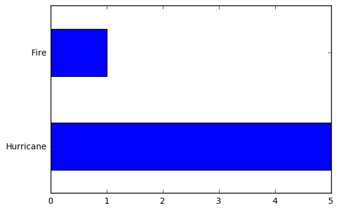

```python
# Disasters in New York County

ny_dis = disaster[disaster['county'] == 'New York County']
ny_dis['disaster_type'].value_counts().plot.barh()
plt.show()
```

```python
NY
```

|  | date_seen | date_posted | shape | duration_min | comments | city_raw | city | county | county_fip | zip_code | state | state_abbr | division_name | region_name | latitude | longitude |
| --- | --- | --- | --- | --- | --- | --- | --- | --- | --- | --- | --- | --- | --- | --- | --- | --- |
| 123 | 1965-08-20 20:30:00 | 2002-10-28 | cylinder | 2.000000 | I was 10 years old.My mother and I walked the ... | New York City (Brooklyn) | New York | New York County | NY-061 | 10007.0 | New York | NY | Mid-Atlantic | Northeast | 40.714167 | -74.006389 |
| 124 | 1965-08-20 20:30:00 | 2006-05-15 | cylinder | 2.000000 | 1965 Dark Grey Cylinder UFO Updated Statement | New York City (Brooklyn) | New York | New York County | NY-061 | 10007.0 | New York | NY | Mid-Atlantic | Northeast | 40.714167 | -74.006389 |
| 157 | 1965-11-15 21:00:00 | 1999-08-10 | oval | 20.000000 | Saw this object directly overhead.....about 65... | New York City (Queens) | New York | New York County | NY-061 | 10007.0 | New York | NY | Mid-Atlantic | Northeast | 40.714167 | -74.006389 |
| 249 | 1966-06-30 05:00:00 | 2014-01-30 | circle | 0.166667 | Orb or throgsneck bridge. | New York City (Bronx) | New York | New York County | NY-061 | 10007.0 | New York | NY | Mid-Atlantic | Northeast | 40.714167 | -74.006389 |
| 297 | 1966-09-01 22:00:00 | 2001-10-12 | sphere | 45.000000 | SITING OF A MASSIVE UFO ABOVE THROGS NECK BRID... | New York City (Queens) | New York | New York County | NY-061 | 10007.0 | New York | NY | Mid-Atlantic | Northeast | 40.714167 | -74.006389 |
| 436 | 1967-08-01 19:00:00 | 2005-07-13 | diamond | 5.000000 | Foreign Object Just Whizzing By Lights Up the ... | New York City (Middle Village) (Queens) | New York | New York County | NY-061 | 10007.0 | New York | NY | Mid-Atlantic | Northeast | 40.714167 | -74.006389 |
| 512 | 1968-03-01 15:00:00 | 2005-09-15 | disk | 2.000000 | I remember it so well to this day. I was in c... | New York City | New York | New York County | NY-061 | 10007.0 | New York | NY | Mid-Atlantic | Northeast | 40.714167 | -74.006389 |
| 850 | 1970-05-01 00:00:00 | 2004-01-17 | other | 5.000000 | Bronx&#44 NY : It was a solid silver -colored... | New York City (Bronx) | New York | New York County | NY-061 | 10007.0 | New York | NY | Mid-Atlantic | Northeast | 40.714167 | -74.006389 |
| 851 | 1970-05-01 00:00:00 | 2004-01-17 | other | 3.000000 | I and scores of others witness a silver pyrami... | New York City (P. S. 54) | New York | New York County | NY-061 | 10007.0 | New York | NY | Mid-Atlantic | Northeast | 40.714167 | -74.006389 |
| 855 | 1970-05-05 19:00:00 | 2004-07-08 | changing | 5.000000 | P.S.154 Sighting in the South Bronx | New York City | New York | New York County | NY-061 | 10007.0 | New York | NY | Mid-Atlantic | Northeast | 40.714167 | -74.006389 |
| 928 | 1970-09-22 23:00:00 | 2004-03-17 | sphere | 2.000000 | While I realize this is reaching a bit far bac... | New York City (Manhattan) | New York | New York County | NY-061 | 10007.0 | New York | NY | Mid-Atlantic | Northeast | 40.714167 | -74.006389 |
| 929 | 1970-10-01 16:00:00 | 2008-01-21 | disk | 3.000000 | Hoovering disk like object by Father and Son&#... | New York City (Brooklyn) | New York | New York County | NY-061 | 10007.0 | New York | NY | Mid-Atlantic | Northeast | 40.714167 | -74.006389 |
| 933 | 1970-10-01 21:00:00 | 2001-02-18 | disk | 5.000000 | Saucer/disklike craft&#44 with multi-colored l... | New York City (Brooklyn) | New York | New York County | NY-061 | 10007.0 | New York | NY | Mid-Atlantic | Northeast | 40.714167 | -74.006389 |
| 1370 | 1973-10-20 00:00:00 | 2009-03-19 | unknown | 60.000000 | 5-6 Star like lights moved single file across ... | New York City (Brooklyn) | New York | New York County | NY-061 | 10007.0 | New York | NY | Mid-Atlantic | Northeast | 40.714167 | -74.006389 |
| 1489 | 1974-06-30 18:30:00 | 2012-09-24 | disk | 15.000000 | Glowing&#44 bi-convex&#44 disc-shaped craft cr... | New York | New York | New York County | NY-061 | 10007.0 | New York | NY | Mid-Atlantic | Northeast | 40.714167 | -74.006389 |
| 1492 | 1974-06-30 21:00:00 | 2012-12-20 | circle | 10.000000 | When we were asked to leave. | New York City (Bronx) | New York | New York County | NY-061 | 10007.0 | New York | NY | Mid-Atlantic | Northeast | 40.714167 | -74.006389 |
| 2107 | 1976-09-10 22:00:00 | 2002-05-14 | disk | 15.000000 | 1976 Sighting - 2 disks over NY city. | New York City (Bronx) | New York | New York County | NY-061 | 10007.0 | New York | NY | Mid-Atlantic | Northeast | 40.714167 | -74.006389 |
| 2155 | 1977-01-01 19:30:00 | 2005-09-02 | sphere | 1.000000 | A small gray ball moved past my bedroom window... | New York City (Manhattan) | New York | New York County | NY-061 | 10007.0 | New York | NY | Mid-Atlantic | Northeast | 40.714167 | -74.006389 |
| 2488 | 1978-06-30 21:00:00 | 2010-02-14 | oval | 15.000000 | It was clear as day and there was NO mistake | New York City (Bronx) | New York | New York County | NY-061 | 10007.0 | New York | NY | Mid-Atlantic | Northeast | 40.714167 | -74.006389 |
| 2542 | 1978-07-20 02:00:00 | 2005-09-02 | triangle | 3.000000 | Retired Police Officer:Triangle shape&#44 with... | New York City (Brooklyn) | New York | New York County | NY-061 | 10007.0 | New York | NY | Mid-Atlantic | Northeast | 40.714167 | -74.006389 |
| 2812 | 1979-08-15 18:00:00 | 2009-03-19 | disk | 7.000000 | August 1979&#44 sighting in broad daylight ove... | West New York | New York | New York County | NaN | 10024.0 | New Jersey | NJ | Mid-Atlantic | Northeast | 40.783060 | -73.971249 |
| 2827 | 1979-09-01 19:30:00 | 2004-01-17 | disk | 1.000000 | Major UFO seen over Brooklyn New York &quot;It... | New York City (Brooklyn) | New York | New York County | NY-061 | 10007.0 | New York | NY | Mid-Atlantic | Northeast | 40.714167 | -74.006389 |
| 3295 | 1982-06-15 19:00:00 | 2004-01-17 | cigar | 5.000000 | Three UFOs disguised as &quot;Clouds&quot; | New York City (Staten Island) | New York | New York County | NY-061 | 10007.0 | New York | NY | Mid-Atlantic | Northeast | 40.714167 | -74.006389 |
| 3316 | 1982-07-01 20:00:00 | 2007-10-08 | disk | 0.083333 | Walking home in Manhattan summer 1982 we witne... | New York City (Manhattan) | New York | New York County | NY-061 | 10007.0 | New York | NY | Mid-Atlantic | Northeast | 40.714167 | -74.006389 |
| 3474 | 1983-07-10 20:00:00 | 2007-02-01 | fireball | 0.083333 | FireBall in the Bronx...... Early 80&quot;s | New York City (Bronx) | New York | New York County | NY-061 | 10007.0 | New York | NY | Mid-Atlantic | Northeast | 40.714167 | -74.006389 |
| 3605 | 1984-07-01 21:30:00 | 2003-09-28 | triangle | 15.000000 | 6-8 light formation moving slowly w/o sound | New York City (Yonkers) | New York | New York County | NY-061 | 10007.0 | New York | NY | Mid-Atlantic | Northeast | 40.714167 | -74.006389 |
| 3656 | 1984-09-20 21:00:00 | 2005-05-11 | teardrop | 5.000000 | BRIGHT WHITE LIGHTS SEEN IN THE BRONX IN THE ... | New York City (Bronx) | New York | New York County | NY-061 | 10007.0 | New York | NY | Mid-Atlantic | Northeast | 40.714167 | -74.006389 |
| 3706 | 1985-04-01 15:00:00 | 2005-10-11 | changing | 10.000000 | Strange thing that changed into a pearl. | New York City | New York | New York County | NY-061 | 10007.0 | New York | NY | Mid-Atlantic | Northeast | 40.714167 | -74.006389 |
| 3762 | 1985-06-15 23:00:00 | 2008-02-14 | oval | 1.000000 | Bright light over Sun Set Park&#44 viewed fro... | New York City (Brooklyn) | New York | New York County | NY-061 | 10007.0 | New York | NY | Mid-Atlantic | Northeast | 40.714167 | -74.006389 |
| 3861 | 1985-10-22 20:00:00 | 2003-07-16 | sphere | 2.000000 | I was very young at the time but i remember th... | New York City | New York | New York County | NY-061 | 10007.0 | New York | NY | Mid-Atlantic | Northeast | 40.714167 | -74.006389 |
| ... | ... | ... | ... | ... | ... | ... | ... | ... | ... | ... | ... | ... | ... | ... | ... | ... |
| 3913 | 1986-05-15 17:40:00 | 2005-10-20 | chevron | 40.000000 | Metallic UFO over Upper Manhattan | New York City (Manhattan) | New York | New York County | NY-061 | 10007.0 | New York | NY | Mid-Atlantic | Northeast | 40.714167 | -74.006389 |
| 3920 | 1986-06-01 19:00:00 | 2001-01-03 | triangle | 3.000000 | looking at night sky a large spaceship the si... | New York City (Brooklyn) | New York | New York County | NY-061 | 10007.0 | New York | NY | Mid-Atlantic | Northeast | 40.714167 | -74.006389 |
| 3995 | 1986-09-15 03:00:00 | 2008-04-17 | sphere | 25.000000 | A clear bright starry night. Very nice indeed ... | New York City (Brooklyn) | New York | New York County | NY-061 | 10007.0 | New York | NY | Mid-Atlantic | Northeast | 40.714167 | -74.006389 |
| 4059 | 1987-03-17 21:00:00 | 2007-11-28 | chevron | 15.000000 | St. Patrick&#39s Day 1987 - Lights over the Br... | New York City (Bronx) | New York | New York County | NY-061 | 10007.0 | New York | NY | Mid-Atlantic | Northeast | 40.714167 | -74.006389 |
| 4095 | 1987-06-01 15:00:00 | 2006-10-30 | cigar | 5.000000 | Three fast moving violently churning out of pl... | New York City (Staten Island) | New York | New York County | NY-061 | 10007.0 | New York | NY | Mid-Atlantic | Northeast | 40.714167 | -74.006389 |
| 4149 | 1987-07-21 23:00:00 | 2002-10-15 | oval | 60.000000 | above-city sighting of oval-shaped U.F.O. duri... | New York City (Brooklyn) | New York | New York County | NY-061 | 10007.0 | New York | NY | Mid-Atlantic | Northeast | 40.714167 | -74.006389 |
| 4253 | 1988-03-17 19:30:00 | 2004-04-27 | oval | 105.000000 | YONKERS&#44 NY | New York City (Yonkers) | New York | New York County | NY-061 | 10007.0 | New York | NY | Mid-Atlantic | Northeast | 40.714167 | -74.006389 |
| 4346 | 1988-08-01 13:30:00 | 2003-09-24 | sphere | 0.500000 | Two perfectly round&#44 silver spheres fly ove... | West New York | New York | New York County | NaN | 10024.0 | New Jersey | NJ | Mid-Atlantic | Northeast | 40.783060 | -73.971249 |
| 4388 | 1988-09-20 18:00:00 | 2010-11-21 | circle | 10.000000 | looking up clear as day a huge bright light&#4... | New York City (Staten Island) | New York | New York County | NY-061 | 10007.0 | New York | NY | Mid-Atlantic | Northeast | 40.714167 | -74.006389 |
| 4413 | 1988-10-22 20:30:00 | 2003-10-31 | sphere | 1.000000 | Sphere coming out from the Moon | New York City (Queens) | New York | New York County | NY-061 | 10007.0 | New York | NY | Mid-Atlantic | Northeast | 40.714167 | -74.006389 |
| 4471 | 1989-04-19 20:00:00 | 2007-04-27 | other | 10.000000 | Weird collection of lights hovers over Manhatt... | New York City | New York | New York County | NY-061 | 10007.0 | New York | NY | Mid-Atlantic | Northeast | 40.714167 | -74.006389 |
| 4507 | 1989-06-01 23:00:00 | 2007-08-14 | unknown | 180.000000 | Alien working in a store in a busy neigborhood... | New York City | New York | New York County | NY-061 | 10007.0 | New York | NY | Mid-Atlantic | Northeast | 40.714167 | -74.006389 |
| 4905 | 1991-05-01 01:00:00 | 2007-11-28 | circle | 5.000000 | In the summer of 1991 around the months of May... | New York City (Brooklyn) | New York | New York County | NY-061 | 10007.0 | New York | NY | Mid-Atlantic | Northeast | 40.714167 | -74.006389 |
| 4955 | 1991-06-23 22:00:00 | 2012-06-08 | other | 60.000000 | 22:00 hrs far rockaway n.y. | New York City (Far Rockaway) (Queens) | New York | New York County | NY-061 | 10007.0 | New York | NY | Mid-Atlantic | Northeast | 40.714167 | -74.006389 |
| 5127 | 1992-06-01 08:15:00 | 2001-10-12 | cigar | 12.000000 | cigar like encounter | New York City | New York | New York County | NY-061 | 10007.0 | New York | NY | Mid-Atlantic | Northeast | 40.714167 | -74.006389 |
| 5137 | 1992-06-05 13:00:00 | 2011-01-05 | light | 0.416667 | ((HOAX??)) 1992 UFOs over Manhattan. | New York City (Manhattan) | New York | New York County | NY-061 | 10007.0 | New York | NY | Mid-Atlantic | Northeast | 40.714167 | -74.006389 |
| 5233 | 1992-09-12 22:15:00 | 2001-08-05 | teardrop | 5.000000 | Manhattan UFO | New York City (Manhattan) | New York | New York County | NY-061 | 10007.0 | New York | NY | Mid-Atlantic | Northeast | 40.714167 | -74.006389 |
| 5261 | 1992-10-19 14:00:00 | 2012-09-24 | disk | 0.133333 | Octagan craft with lights over a hundred feet ... | New York City (Jamaica) (Queens) | New York | New York County | NY-061 | 10007.0 | New York | NY | Mid-Atlantic | Northeast | 40.714167 | -74.006389 |
| 5274 | 1992-11-18 19:00:00 | 2004-01-31 | formation | 5.000000 | Pool Rack formation seen over an Army Base in ... | New York City (Brooklyn) | New York | New York County | NY-061 | 10007.0 | New York | NY | Mid-Atlantic | Northeast | 40.714167 | -74.006389 |
| 5304 | 1993-02-26 05:00:00 | 2008-10-31 | light | 0.020000 | Bright White High Speed Light over Newark New ... | New York City | New York | New York County | NY-061 | 10007.0 | New York | NY | Mid-Atlantic | Northeast | 40.714167 | -74.006389 |
| 5409 | 1993-06-30 20:00:00 | 2011-10-10 | other | 2.500000 | V shaped lights.huge.noisless.flying very slow | New York City (Yonkers) | New York | New York County | NY-061 | 10007.0 | New York | NY | Mid-Atlantic | Northeast | 40.714167 | -74.006389 |
| 5422 | 1993-07-04 03:00:00 | 2002-07-01 | other | 45.000000 | three light U.F.O.&#39s in the night | New York City | New York | New York County | NY-061 | 10007.0 | New York | NY | Mid-Atlantic | Northeast | 40.714167 | -74.006389 |
| 5606 | 1994-05-11 22:00:00 | 1999-10-02 | circle | 0.250000 | I observed a round black object pass in front ... | New York City (Brooklyn) | New York | New York County | NY-061 | 10007.0 | New York | NY | Mid-Atlantic | Northeast | 40.714167 | -74.006389 |
| 5697 | 1994-07-11 17:10:00 | 2005-09-02 | disk | 0.116667 | I just turned around for 1/2 a second&#44 and ... | New York City (Brooklyn) | New York | New York County | NY-061 | 10007.0 | New York | NY | Mid-Atlantic | Northeast | 40.714167 | -74.006389 |
| 5733 | 1994-08-07 22:00:00 | 2003-04-22 | oval | 2.000000 | i know what i saw | New York City (Staten Island) | New York | New York County | NY-061 | 10007.0 | New York | NY | Mid-Atlantic | Northeast | 40.714167 | -74.006389 |
| 5763 | 1994-08-25 11:45:00 | 2000-06-21 | egg | 5.000000 | Observation of egg blimp shapped object in fro... | New York City | New York | New York County | NY-061 | 10007.0 | New York | NY | Mid-Atlantic | Northeast | 40.714167 | -74.006389 |
| 5764 | 1994-08-25 12:00:00 | 2000-06-06 | egg | 1.000000 | no light and moved very slowly | New York City | New York | New York County | NY-061 | 10007.0 | New York | NY | Mid-Atlantic | Northeast | 40.714167 | -74.006389 |
| 5773 | 1994-09-01 02:00:00 | 2011-05-02 | light | 180.000000 | 5 LIGHT THAT LOOKED LIKE STARS MOVING UP AND D... | New York City | New York | New York County | NY-061 | 10007.0 | New York | NY | Mid-Atlantic | Northeast | 40.714167 | -74.006389 |
| 5800 | 1994-10-01 13:13:00 | 2007-06-12 | disk | 0.250000 | a flying colorful disc above my car&#44 near E... | New York City | New York | New York County | NY-061 | 10007.0 | New York | NY | Mid-Atlantic | Northeast | 40.714167 | -74.006389 |
| 6277 | 1995-06-10 23:00:00 | 2014-01-16 | triangle | 0.166667 | Boomerang or Triangular 5 Blueish White Lights. | New York | New York | New York County | NY-061 | 10007.0 | New York | NY | Mid-Atlantic | Northeast | 40.714167 | -74.006389 |

61 rows × 16 columns